# Tell don’t just show: Eplanatory narratives improve recall more than exploratory interactivity for communicative visualizations

Anonymous

### Introduction

This document contains our analysis from our paper, *Tell don’t just show: Eplanatory narratives improve recall more than exploratory interactivity for communicative visualizations*, using R code and the associated output.

### Setup

#### Required libraries

If you are missing any of the packages below, use `install.packages("packagename")` to install them. The `import::` syntax requires the `import` package to be installed, and provides a simple way to import specific functions from a package without polluting your entire namespace (unlike `library()`)

```r
library(knitr)
opts_chunk$set(cache=FALSE, autodep=TRUE, cache.comments=FALSE,
               message=FALSE, warning=FALSE)
library(tidyverse)
library(rstan)
library(brms)
library(magrittr)
library(modelr)
library(tidybayes)
library(rstanarm)

rstan_options(auto_write = TRUE)
options(mc.cores = parallel::detectCores())

theme_set(theme_minimal())
```

### Pre-registered Analysis

For this analysis, we filter out the participants who have failed the attention check question (i.e. answered True to Q11). We then convert the data into long format, evaluate the responses (whether or not the participant correctly answered the question), and convert the columns into appropriate data formats so that we can conveniently fit the model

```r
df = read.csv('data/processed/formatted_vis_interpretation_responses.csv', header=TRUE)
answer_key = read.csv('data/answers.csv', header=TRUE)

analysed_filtered_responses = df %>%
  filter( Q11 == 0 ) %>%
  gather(., question, response,
                 c('Q1', 'Q2', 'Q3', 'Q4', 'Q5', 'Q6', 'Q7', 'Q8', 'Q9', 'Q10', 'Q11'),
                 factor_key=TRUE) %>%
  mutate( response  = as.logical(response)) %>%
  select(ResponseId, question, everything())%>%
  inner_join(x = ., y = answer_key, by = c("question", "vis")) %>%
  mutate(
    question = factor(question),
    correct = as.numeric((answer == response))
  ) %>%
  filter(question != "Q11")
```

### Model

We fit the following multilevel logistic regression model to estimate the probability of answering a question correctly using interactivity and narrative as population-level effects. Group-level effects are included for each participant, question (varying intercepts) and visualization (varying slopes). For the interested reader we provide the complete model and prior family specification:

$$\begin{align}
Y_i &\sim \textrm{Binomial}(n_{i}, p_{i}) \\
logit[p_{i}] &= \alpha + \alpha_{i} + \alpha_{vis[i]} + \alpha_{j, vis[i]} + \\ & (\beta_{int} + \gamma_{int, vis[i]}) x_{int} + \\ & (\beta_{narr} + \gamma_{narr, vis[i]}) x_{narr} + \\ & (\beta_{narr \times int} + \gamma_{narr \times int, vis[i]}) x_{narr} x_{int}
\end{align}$$

$$\begin{align}
\alpha_{i}, \alpha_{j, vis[i]} &\sim \mathrm{Normal}(0, \theta) \\
\theta &\sim \mathrm{t}(3, 0, 10) \\
\alpha, \beta_{int}, \beta_{narr}, \beta_{narr \times int} &\sim \mathrm{Normal}(0, 1) \\
\begin{bmatrix}
\alpha_{vis[i]} \\
\gamma_{int, vis[i]} \\
\gamma_{narr, vis[i]} \\
\gamma_{int \times narr, vis[i]}
\end{bmatrix} &\sim \mathrm{MVN}(0, \Sigma) \\
\end{align}$$

$$\begin{align}
\Sigma &\sim
\begin{pmatrix}
\sigma_{\alpha} & 0 & 0 & 0 \\
0 & \sigma_{int} & 0 & 0 \\
0 & 0 & \sigma_{narr} & 0 \\
0 & 0 & 0 & \sigma_{int \times narr}
\end{pmatrix}
R
\begin{pmatrix}
\sigma_{\alpha} & 0 & 0 & 0 \\
0 & \sigma_{int} & 0 & 0 \\
0 & 0 & \sigma_{narr} & 0 \\
0 & 0 & 0 & \sigma_{int \times narr}
\end{pmatrix}
\end{align}$$

$$\begin{align}
\begin{pmatrix}
\sigma_{\alpha} & \sigma_{int} & \sigma_{narr} & \sigma_{int \times narr}
\end{pmatrix}
&\sim
\mathrm{t} (3, 0, 10) \\
\mathrm{R} \sim LKJcorr(1)
\end{align}$$

Variables:

- $i = 1... I$ indexes persons (respondents of the survey)
- $j = 1...J$ indexes items / number of questions on the questionnaire. Here, $J = 11$
- $vis[i] = 1...K$ indexes the number of visualizations for a participant, i. Here $K = 4$
- $y_{i} \in {0, 1}$ is the response by participant i.

Parameters:

- $\gamma_{vis[i]}$ is the coefficient for random slope for a visualization, $m$
- $\alpha_{i}$ is the random intercept due to the ability of a person $i$
- $\alpha_{vis[i]}$ is the random intercept due to each visualization
- $\alpha_{j}$ is the random intercept due to the difficulty of each question $j$, in each visualization

We fit the model using the brms package. In this document we load a pre-fitted model instead. To run the model and perform the analysis, uncomment the model command.

```r
# Load the model instead of fitting it
fit_conditions_filtered = brm(correct ~ interactivity*narrative + (1|ResponseId) + (interactivity*narrative|vis) + (1|question:vis),  data = analysed_filtered_responses, family = "bernoulli", prior=prior(normal(0, 1), class=b), iter = 5000, chains = 2)
```

### Results

#### Primary analysis

In our primary analysis we compare the (population-level) effects of narrative and interactivity on insight (measured using the probability of answering a question correctly). In what follows, we plot the **marginal posterior estimates** of the probability of answering a (typical) question correctly. We provide the posterior probability density, posterior mean point estimate and 66% and 95% quantile intervals. The marks represent the raw proportions of questions answered correctly in each condition.

Marginal estimates are calculated by integrating over the other variables (in this case, visualization) to obtain the average effect for visualization. In other words we obtain the estimate for the probability of answering a typical question correctly given one of our designs, by a typical participant, on average.

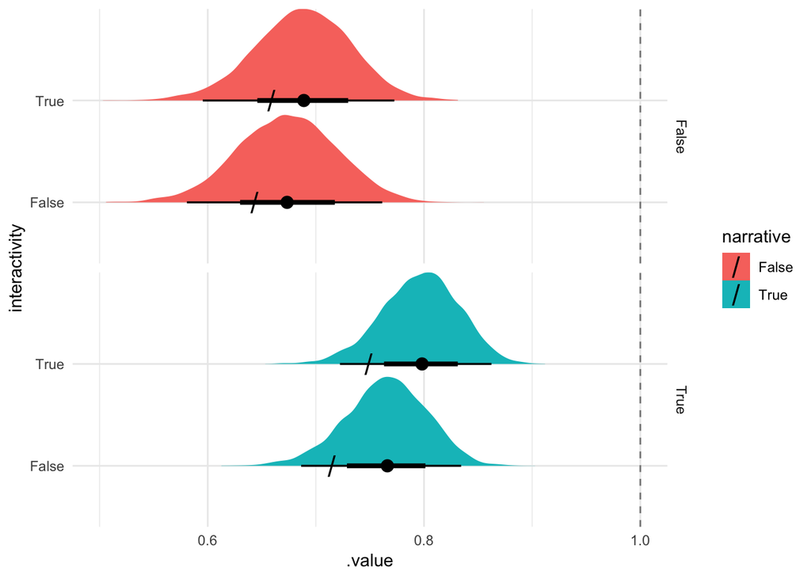

```r
fixed_effects_estimates <- analysed_filtered_responses %>%
  data_grid(interactivity, narrative, vis) %>%
  add_fitted_draws(fit_conditions_filtered, re_formula = ~(interactivity * narrative | vis)) %>%
  ungroup() %>%
  group_by(interactivity, narrative, .draw) %>%
  summarise(.value = mean(.value))

raw_scores <- analysed_filtered_responses %>%
  group_by(narrative, interactivity) %>%
  summarise(.value = mean(correct))

plot <- fixed_effects_estimates %>%
  ggplot(aes(y = interactivity, x = .value, fill = narrative)) +
  geom_halfeyeh() +
  facet_grid(narrative ~ .) +
  coord_cartesian(xlim = c(0.5, 1)) +
  scale_x_continuous(breaks = seq(0, 1, by = 0.2)) +
  geom_vline(xintercept = 0, lty = 2, alpha = 0.5) +
  geom_vline(xintercept = 1, lty = 2, alpha = 0.5) +
  geom_point(data = raw_scores, aes(x = .value, y = interactivity), size = 6, shape = 47)

plot
```

We could also estimate the probability of answering, on average, for the questions we have tested on our questionnaire, by a typical participant. This is the estimate marginalised over *question* (averages the variance associated with a typical question) and hence the estimates obtained are less uncertain.

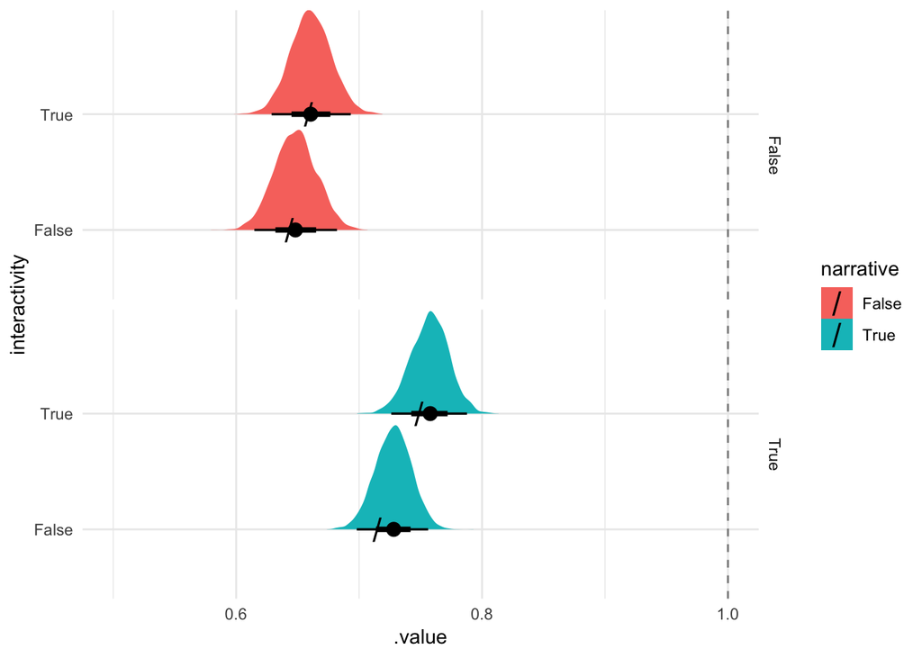

```r
fixed_effects_estimates <- analysed_filtered_responses %>%
  data_grid(interactivity, narrative, question, vis) %>%
  filter(question != "Q11") %>%
  add_fitted_draws(fit_conditions_filtered, re_formula = ~((interactivity * narrative | vis) + (1 | question:vis))) %>%
  ungroup() %>%
  group_by(interactivity, narrative, .draw) %>%
  summarise(.value = mean(.value))

raw_scores <- analysed_filtered_responses %>%
  group_by(narrative, interactivity) %>%
  summarise(.value = mean(correct))

fixed_effects_estimates %>%
  ggplot(aes(y = interactivity, x = .value, fill = narrative)) +
  geom_halfeyeh() +
  facet_grid(narrative ~ .) +
  coord_cartesian(xlim = c(0.5, 1)) +
  scale_x_continuous(breaks = seq(0, 1, by = 0.2)) +
  geom_vline(xintercept = 0, lty = 2, alpha = 0.5) +
  geom_vline(xintercept = 1, lty = 2, alpha = 0.5) +
  geom_point(data = raw_scores, aes(x = .value, y = interactivity), size = 6, shape = 47)
```

This shows the conditional and marginal estimates for the effect of narrative. We plot the mean point estimate, 66% & 95% CI and the posterior densities in the probability of answering a (average) question correctly for the difference between narrative and non-narrative conditions

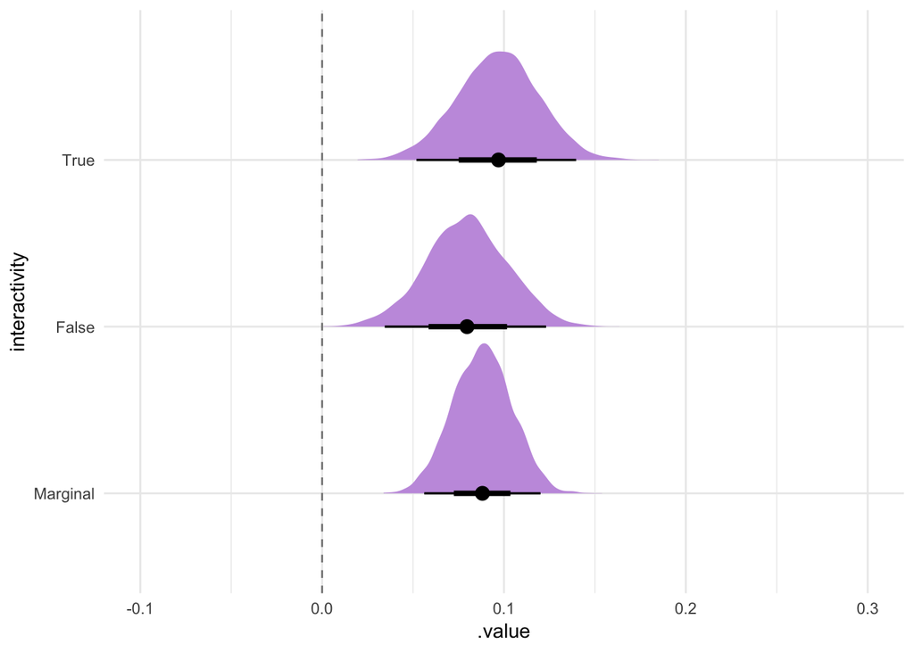

```r
fixed_effects_estimates %<>%
  ungroup() %>%
  mutate(
    narrative = as.character(narrative),
    interactivity = as.character(interactivity)
  )

rbind(
  fixed_effects_estimates %>%
    group_by(interactivity) %>%
    compare_levels(.value, narrative),
  fixed_effects_estimates %>%
    group_by(interactivity) %>%
    compare_levels(.value, narrative) %>%
    group_by(narrative, .draw) %>%
    summarise(.value = mean(.value)) %>%
    mutate(interactivity = "Marginal")
) %>%
  ungroup() %>%
  mutate(interactivity = fct_relevel(interactivity, "Marginal")) %>%
  #group_by(interactivity) %>%  mean_qi(.value, .width = .95)
  ggplot(aes(y = interactivity, x = .value)) +
  geom_halfeyeh(fill = "#c69de0") +
  coord_cartesian(xlim = c(-0.1, 0.3)) +
  scale_x_continuous(breaks = seq(-1, 1, by = 0.1)) +
  geom_vline(xintercept = 0, lty = 2, alpha = 0.5)
```

This shows the conditional and marginal estimates for the effect of interactivity. We plot the mean point estimate, 66% & 95% CI and the posterior densities in the probability of answering a (average) question correctly for the difference between interactive and non-interactive conditions.

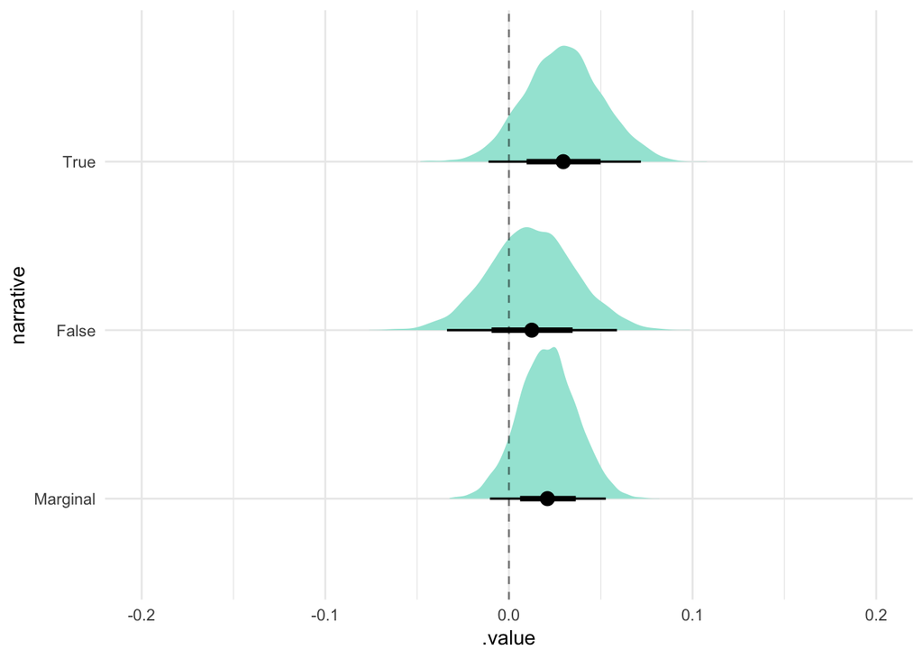

```r
rbind(
  fixed_effects_estimates %>%
    group_by(narrative) %>%
    compare_levels(.value, interactivity),
  fixed_effects_estimates %>%
    group_by(narrative) %>%
    compare_levels(.value, interactivity) %>%
    group_by(interactivity, .draw) %>%
    summarise(.value = mean(.value)) %>%
    mutate(narrative = "Marginal")
) %>%
  ungroup() %>%
  mutate(narrative = fct_relevel(narrative, "Marginal")) %>%
  #group_by(narrative) %>%  mean_qi(.value, .width = .95)
  ggplot(aes(y = narrative, x = .value)) +
  geom_halfeyeh(fill = "#a3e5d8") +
  coord_cartesian(xlim = c(-0.2, 0.2)) +
  scale_x_continuous(breaks = seq(-1, 1, by = 0.1)) +
  geom_vline(xintercept = 0, lty = 2, alpha = 0.5)
```

The previous graphs depicted the effects of `explanatory narrative` and `interactivity` conditional on the visualizations used in our study. Our hierarchical model allows us to estimate the effect of `explanatory narrative` and `interactivity` in a new visualization not tested in our study. In the following graph, we show the marginal estimates for the effect of `explanatory narrative` and `interactivity` for a new visualization. Note, that the estimated 95% intervals are wider than the previous graphs to account for the uncertainty associated with a new visualization.

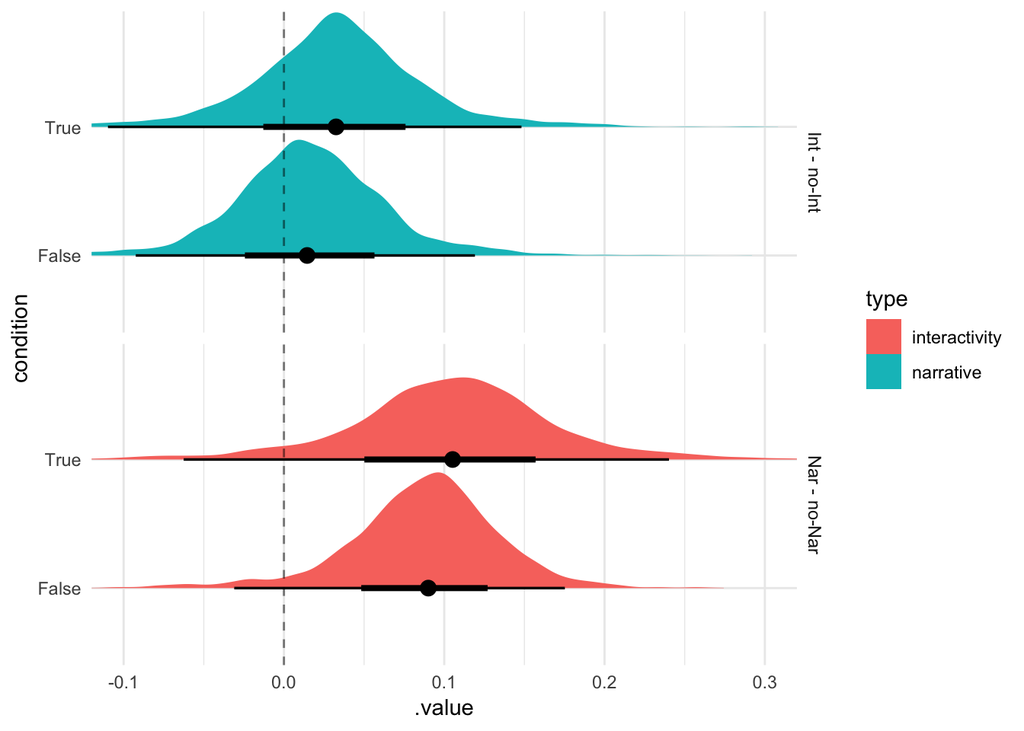

```r
fixed_effects_estimates_new_vis <- analysed_filtered_responses %>%
  data_grid(interactivity, narrative) %>%
  add_fitted_draws(fit_conditions_filtered, re_formula = ~(narrative * interactivity | vis), allow_new_levels = TRUE)

rbind(
  fixed_effects_estimates_new_vis %>%
    compare_levels(.value, interactivity) %>%
    gather(narrative, key = type, value = condition) %>%
    ungroup() %>%
    mutate(interactivity = str_replace(interactivity, "True - False", "Int - no-Int") ) %>%
    rename (diff = interactivity),
  fixed_effects_estimates_new_vis %>%
    compare_levels(.value, narrative) %>%
    gather(interactivity, key = type, value = condition) %>%
    ungroup() %>%
    mutate(narrative = str_replace(narrative, "True - False", "Nar - no-Nar") ) %>%
    rename (diff = narrative)
) %>%
  ggplot(aes(y = condition, x = .value, fill = type)) +
  geom_halfeyeh() +
  coord_cartesian(xlim = c(-0.1, 0.3)) +
  scale_x_continuous(breaks = seq(-1, 1, by = 0.1)) +
  facet_grid(diff ~ .) +
  geom_vline(xintercept = 0, lty = 2, alpha = 0.5)
```

This next two graphs show the conditional and marginal estimates emphasizing the (visualization) group-specific effects. We plot the mean point estimate, 66% & 95% CI and the posterior densities in the probability of answering a (average) question correctly for the difference between 1) narrative and non-narrative, and (2) interactive and non-interactive. This shows that the effects are consistent within each group.

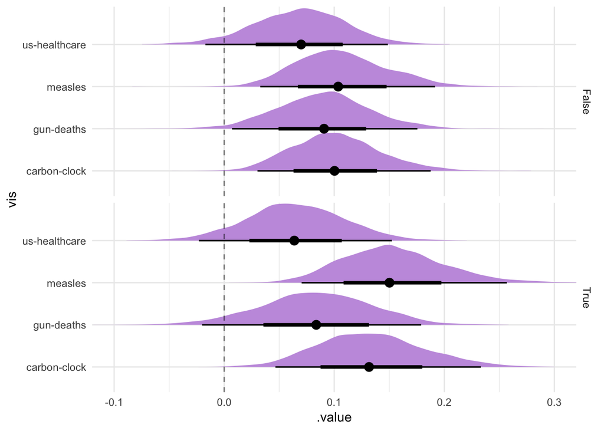

```r
group_effects_estimates <-  analysed_filtered_responses %>%
  data_grid(interactivity, narrative, vis) %>%
  add_fitted_draws(fit_conditions_filtered, re_formula = ~(interactivity*narrative|vis))

group_effects_estimates %>%
  group_by(interactivity, vis) %>%
  compare_levels(.value, narrative) %>%
  ggplot(aes(y = vis, x = .value)) +
  geom_halfeyeh(fill = "#c69de0") +
  facet_grid(interactivity ~ .) +
  coord_cartesian(xlim = c(-0.1, 0.3)) +
  scale_x_continuous(breaks = seq(-1, 1, by = 0.1)) +
  geom_vline(xintercept = 0, lty = 2, alpha = 0.5)
```

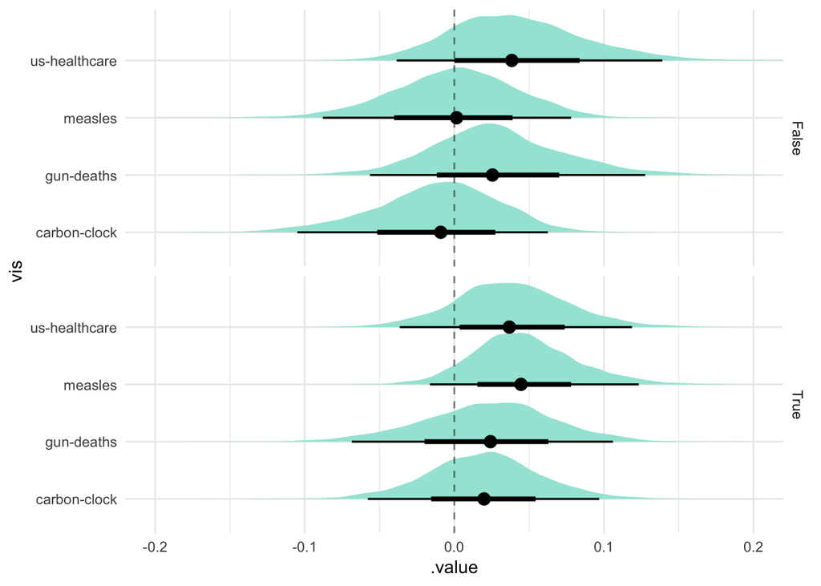

```r
group_effects_estimates %>%
  group_by(narrative, vis) %>%
  compare_levels(.value, interactivity) %>%
  ggplot(aes(y = vis, x = .value)) +
  geom_halfeyeh( fill = "#a3e5d8" ) +
  facet_grid(narrative ~ .) +
  coord_cartesian(xlim = c(-0.2, 0.2)) +
  scale_x_continuous(breaks = seq(-1, 1, by = 0.1)) +
  geom_vline(xintercept = 0, lty = 2, alpha = 0.5)
```

#### Alternate Analysis

```r
analysed_responses = df %>%
  gather(., question, response,
                 c('Q1', 'Q2', 'Q3', 'Q4', 'Q5', 'Q6', 'Q7', 'Q8', 'Q9', 'Q10', 'Q11'),
                 factor_key=TRUE) %>%
  mutate( response  = as.logical(response)) %>%
  .[order(.$ResponseId, .$question),] %>%
  inner_join(x = ., y = answer_key, by = c("question", "vis")) %>%
  mutate(
    question = factor(question),
    vis = factor(vis),
    correct = as.numeric((answer == response)))
```

```r
fit_conditions = brm(correct ~ interactivity*narrative + (1|ResponseId) + (interactivity*narrative|vis) + (1|question:vis), data = analysed_responses, family = "bernoulli", prior=prior(normal(0, 1), class=b), iter = 5000, chains = 2)
```

Posterior density, mean point estimates and 66% and 95% CIs:

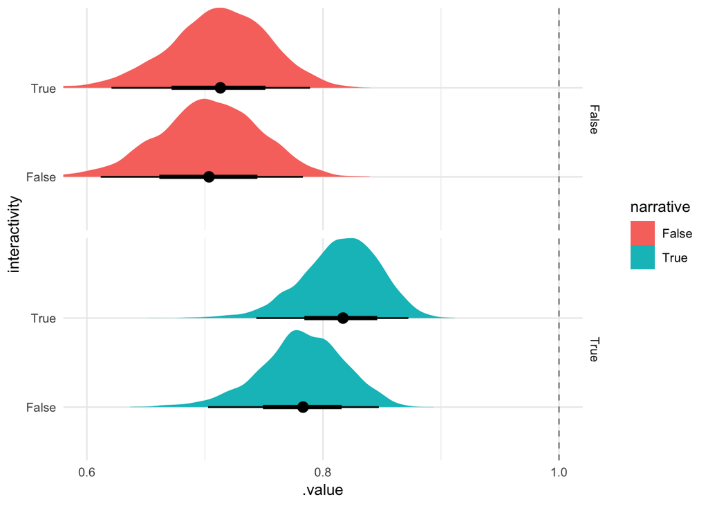

Effect of Narrative:

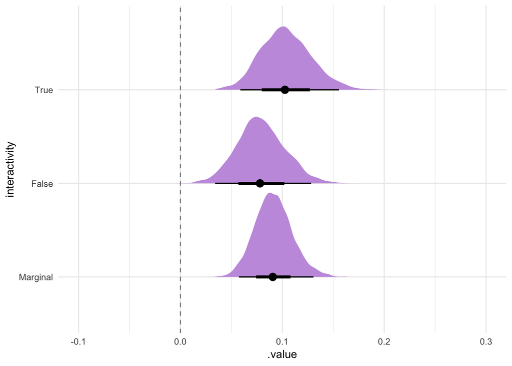

Effect of Interactivity:

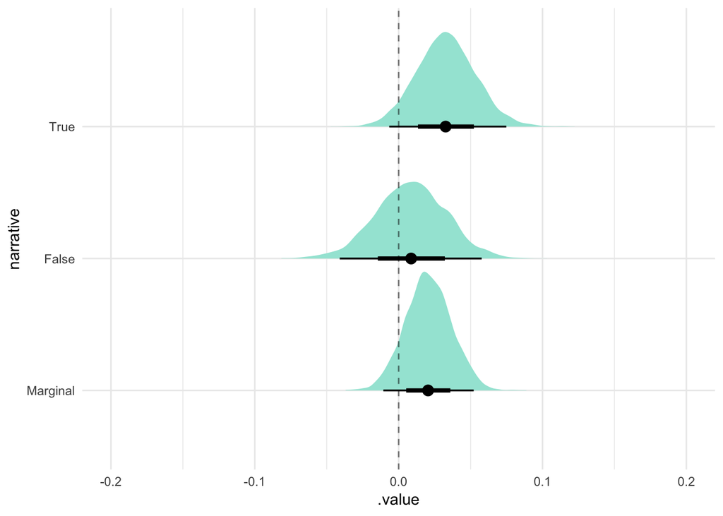

### Exploratory analysis

In our exploratory analysis we investigate whether `narratives` and `interactivity` have an effect on some commonly used measures of engagement such as uptime. We also investigate whether engagement measures can be used to measure insight, by calculating whether more engagement can increase the probability of answering a question correctly.

```r
engagement_measures = read.csv('data/processed/formatted_vis_engagement_logs.csv', header = TRUE)
```

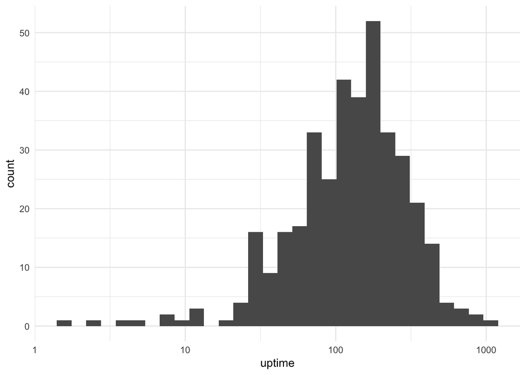

```r
engagement_measures %>%
  ggplot(aes(uptime)) +
  scale_x_log10() +
  geom_histogram()
```

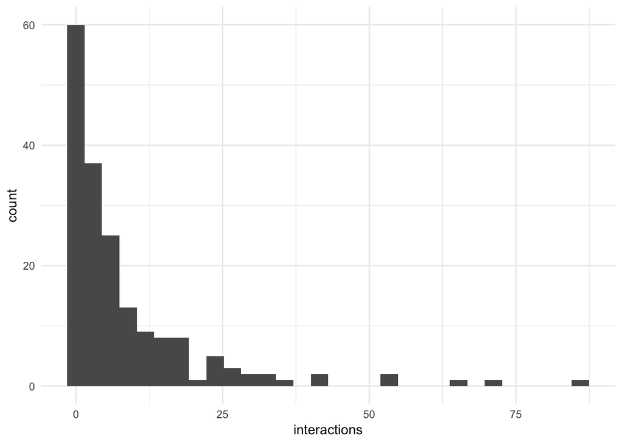

```r
engagement_measures %>%
  filter(interactivity == 'True') %>%
  ggplot(aes(interactions)) +
  geom_histogram()
```

```r
fit_engagement_time = stan_glmer(log(uptime) ~ interactivity*narrative + (interactivity*narrative|vis), data = engagement_measures)

fit_engagement_intx = engagement_measures %>%
  filter(interactivity == "True" & interactions >= 0) %>%
  stan_glmer(interactions ~ narrative + (narrative|vis), data = ., family = neg_binomial_2)
```

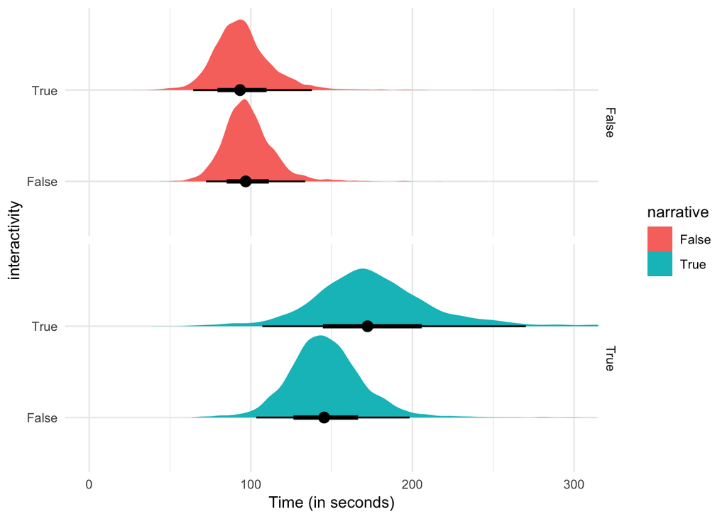

```r
 fixef_engagement <- engagement_measures %>% # this is affecting the data_grid, but we are not interested in the group-level effects
  data_grid(narrative, interactivity) %>%
  add_fitted_draws(fit_engagement_time, re_formula = NA)

fixef_engagement %>%
  ggplot(aes(y = interactivity, x = exp(.value), fill = narrative)) +
  geom_halfeyeh() +
  facet_grid(narrative~.) +
  coord_cartesian(xlim = c(0, 300)) +
  xlab("Time (in seconds)")
```

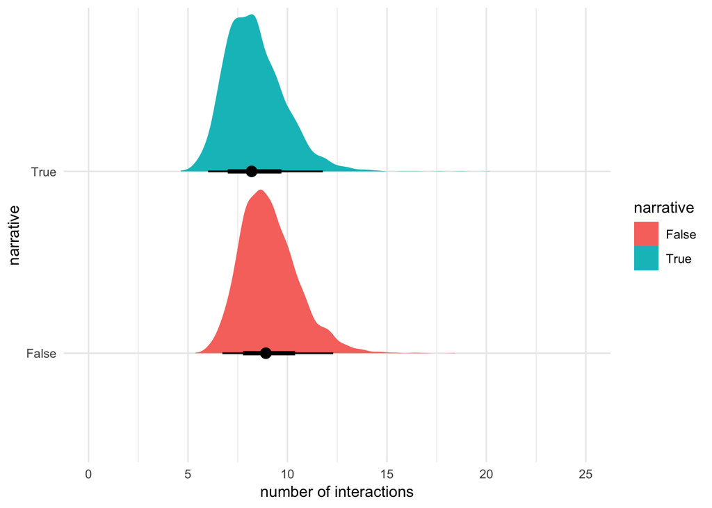

```r
engagement_measures %>% # this is affecting the data_grid, but we are not interested in the group-level effects
  data_grid(narrative, vis) %>%
  add_fitted_draws(fit_engagement_intx, re_formula = ~(narrative|vis)) %>%
  group_by(narrative, .draw) %>%
  summarise(.value = mean(.value)) %>%
  ggplot(aes(y = narrative, x = .value, fill = narrative)) +
  geom_halfeyeh() +
  coord_cartesian(xlim = c(0, 25)) +
  xlab("number of interactions")
```

This is the second part of our exploratory analyses. We investigate whether engagement metrics such as uptime and number of interactions are correlated with insight, since engagement is commonly used as a proxy for insight.

```r
fit_correct_time <- engagement_measures %>%
  filter(interactions > 0 & uptime > 15) %>%
  stan_glmer(correct ~ (log(uptime) | vis), data = .)

fit_correct_intx <- engagement_measures %>%
  filter(interactions > 0 & uptime > 15) %>%
  stan_glmer(correct ~ (interactions | vis), data = .)
```

The following plots show the correlation between the number of correctly answered questions and the metrics of user behavior: `total time spent on the visualizaiton` and `number of non-trivial interactions performed with the visualization` respectively. The raw data is plotted as red points.

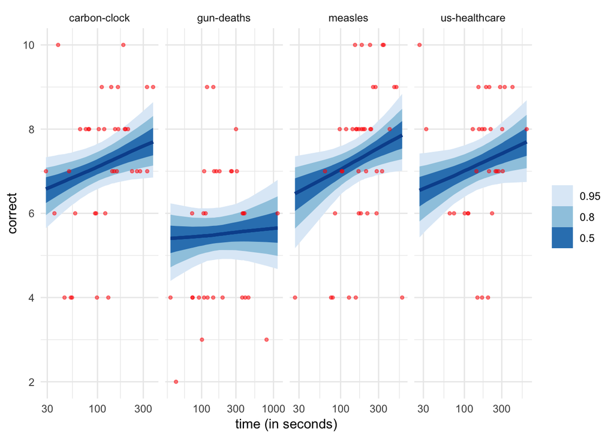

```r
engagement_measures %>%
  filter(interactions > 0 & uptime > 5)  %>%
  add_fitted_draws(fit_correct_time) %>%
  group_by(uptime, .draw, vis) %>%
  summarise(.value = mean(.value)) %>%
  ggplot(aes(x = uptime, y = correct)) +
  stat_lineribbon(aes(y = .value), .width = c(.95, .8, .5), colour = "#08519C") +
  geom_point(data = engagement_measures  %>%  filter(interactions > 0 & uptime > 15), size = 1, colour = "red", alpha = 0.5) +
  scale_fill_brewer() +
  facet_grid(. ~ vis, scales = "free") +
  scale_x_log10() +
  scale_y_continuous(breaks =  seq(0, 10, by = 2)) +
  coord_cartesian(ylim = c(2, 10)) +
  xlab("time (in seconds)")
```

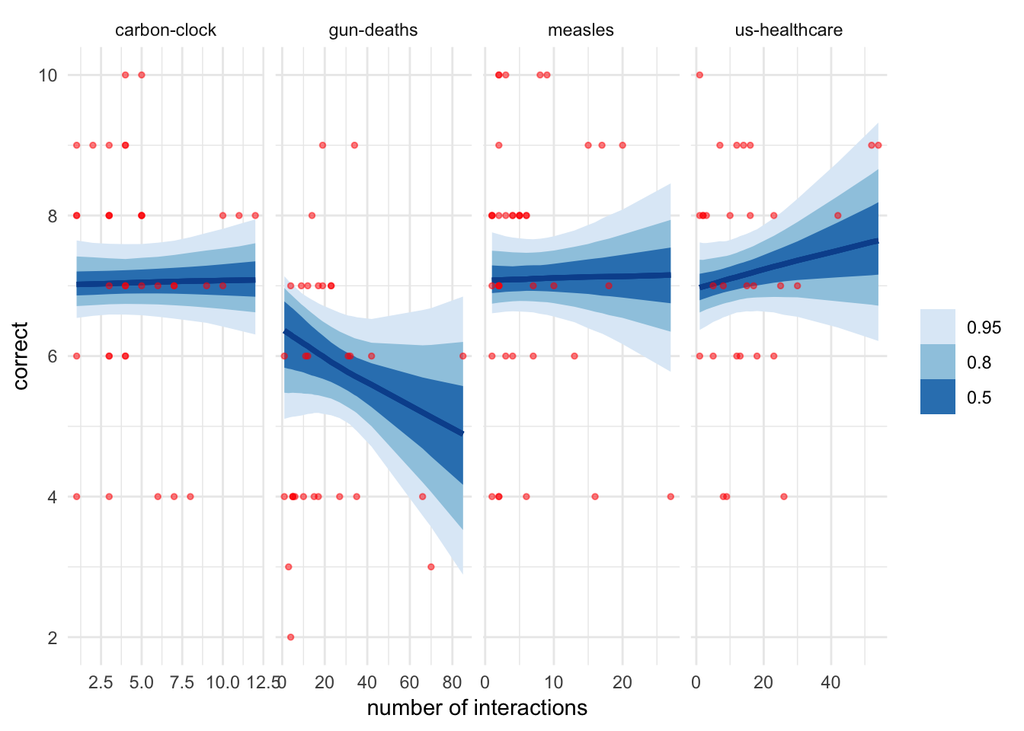

```r
engagement_measures %>%
  filter(interactions > 0 & uptime > 5)  %>%
  add_fitted_draws(fit_correct_intx) %>%
  group_by(interactions, .draw, vis) %>%
  summarise(.value = mean(.value)) %>%
  ggplot(aes(x = interactions, y = correct)) +
  stat_lineribbon(aes(y = .value), .width = c(.95, .8, .5), colour = "#08519C") +
  geom_point(data = engagement_measures  %>%  filter(interactions > 0), size = 1, colour = "red", alpha = 0.5) +
  scale_fill_brewer() +
  facet_grid(. ~ vis, scales = "free")  +
  scale_y_continuous(breaks =  seq(0, 10, by = 2)) +
  coord_cartesian(ylim = c(2, 10)) +
  xlab("number of interactions")
```